# Correspondence analysis of mtcars dataset

Wojciech Artichowicz

7 maja 2018

### Conclusions for stakeholder

#### Based on PCA

- Car models which are close on the plot are similar in terms of examined parameters (mpg,disp,hp,drat,wt,qsec);
- This means that if we want to aim our product at specified customer, we should point with designed car models parameters to be close to one of the groups;
- On the other hand one should take into consideration technical solutions used in particular car type. For example if we want to design a new fast sports car, then solutions similar to ones used in Maserati Bora and Ford Pantera L should be a good first guess; In such case one should possibly take into consideration why those cars have different number of carburetors with similar other parameter values

#### Based on CA of gears vs. carburetors

- Usually cars have 3 or 4 gears along with 1 to 4 carburetors - that is typical if we want to create popular new car;
- Five gears come along with 6 or 8 carburetors in expensive sport cars - hint if we want to aim into exclusive market;
- Middle class expensive sports cars, have 5 gears with 2 carburetors - popular sports car;
- In CA factor map 6 and 8 carburetors are placed in the same point and are the close to 5 gears.

#### Based on CA of cylinders vs. gears

- Most cars have 8 cylinders and 3 gears, or 4 cylinders with 4 gears - for some reason those are typical constructions;
- Least significant technical solution is 6 cylinders and 5 gears - untypical / unpopular?;
- The strong data variability exists only in PCA1 direction, that may indicate that there is strong dependence of number of gears and cylinders.

### Data science part

```r
data("mtcars")  #loading dataset
head(mtcars,5)
```

```
##                    mpg cyl disp  hp drat    wt  qsec vs am gear carb
## Mazda RX4         21.0   6  160 110 3.90 2.620 16.46  0  1    4    4
## Mazda RX4 Wag     21.0   6  160 110 3.90 2.875 17.02  0  1    4    4
## Datsun 710        22.8   4  108  93 3.85 2.320 18.61  1  1    4    1
## Hornet 4 Drive    21.4   6  258 110 3.08 3.215 19.44  1  0    3    1
## Hornet Sportabout 18.7   8  360 175 3.15 3.440 17.02  0  0    3    2
```

### 1. General PCA performed on the dataset

#### Remark

To search for possible correlation dependencies PCA was performed on continuous and ordinal variables. Categorical variables were neglected.

#### Data science comment

PCA creates a new projection of the features in such way that new features are not correlated. Arrows (noted with variables) on the plot show correlations. Arrows pointing along similarly sloped lines are correlated. If the arrow heads are in the same direction, they are correlated positively, otherwise negatively.

Variables (for example car entities) plotted on such plot depict the poistion of that points in the new features space projected onto plane of chosen directions. If points are close they are somewhat similar, if they are far they significantly different.

Scree plot shows the amount of information in each of the new variables.For example here ~69% of the total dataset variability is “compressed” into first PCA.

Contribution plots show how strong is the influence of each variable to given new feature.

Similar explanations hold for correspondence analysis.

```r
   PCAreduced <- PCA(mtcars[c("mpg","disp","hp","drat","wt","qsec")], scale.unit = TRUE, ncp = 6, graph = FALSE)

print(PCAreduced$eig)
```

```
##        eigenvalue percentage of variance cumulative percentage of variance
## comp 1 4.18739648             69.7899413                          69.78994
## comp 2 1.14811212             19.1352020                          88.92514
## comp 3 0.33335666              5.5559444                          94.48109
## comp 4 0.15436054              2.5726757                          97.05376
## comp 5 0.12479601              2.0799335                          99.13370
## comp 6 0.05197818              0.8663031                         100.00000
```

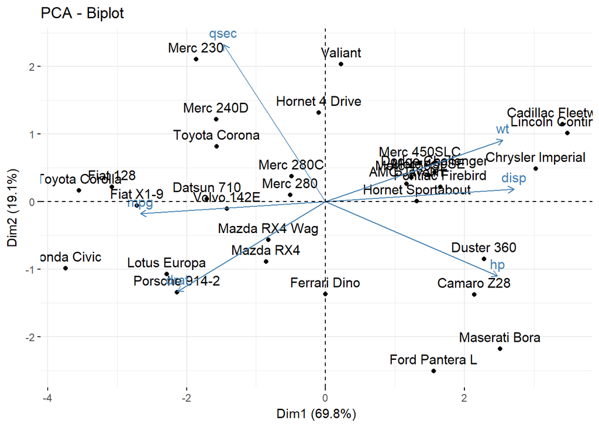

```r
fviz_pca_biplot(PCAreduced)
```

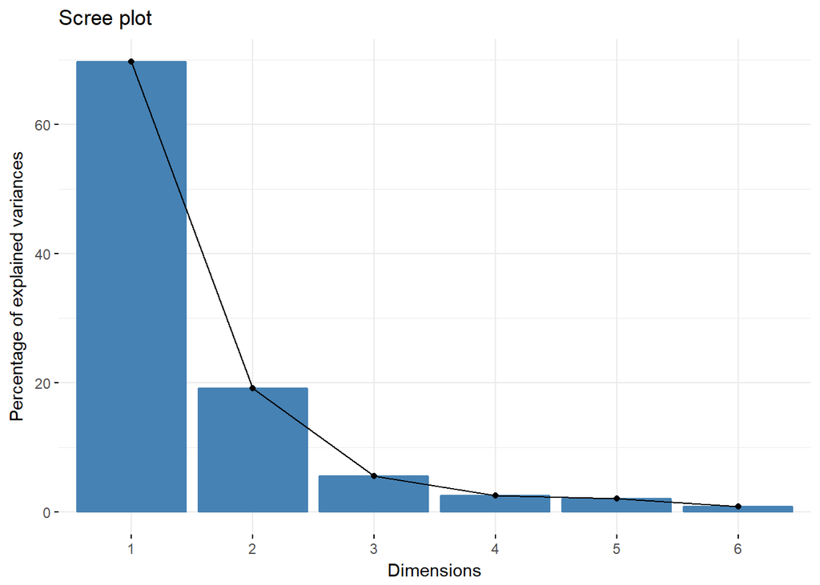

```r
fviz_screeplot(PCAreduced)
```

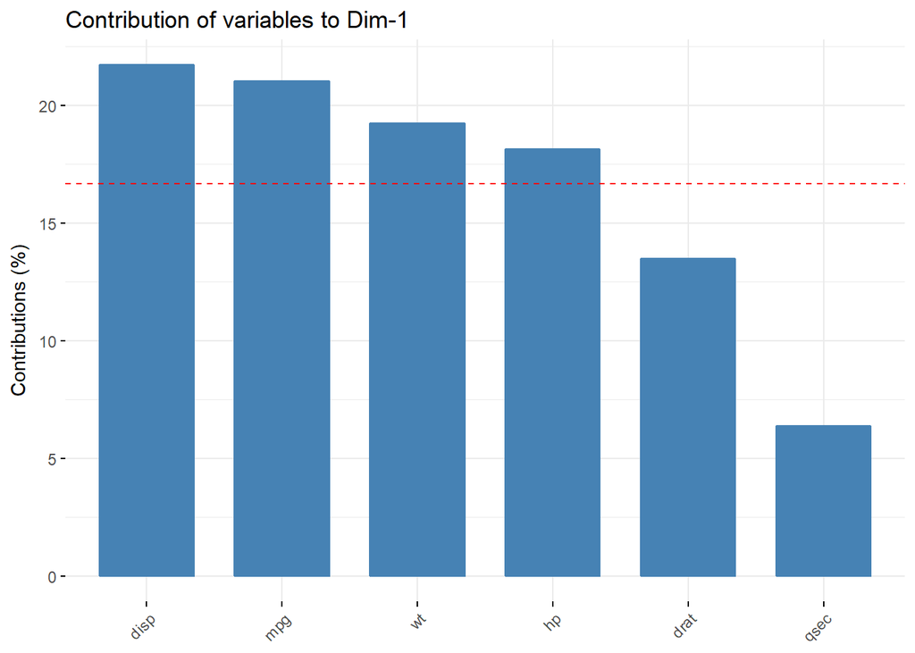

```r
fviz_contrib(PCAreduced,choice = "var",axes = 1, top = 10)  #dim 1
```

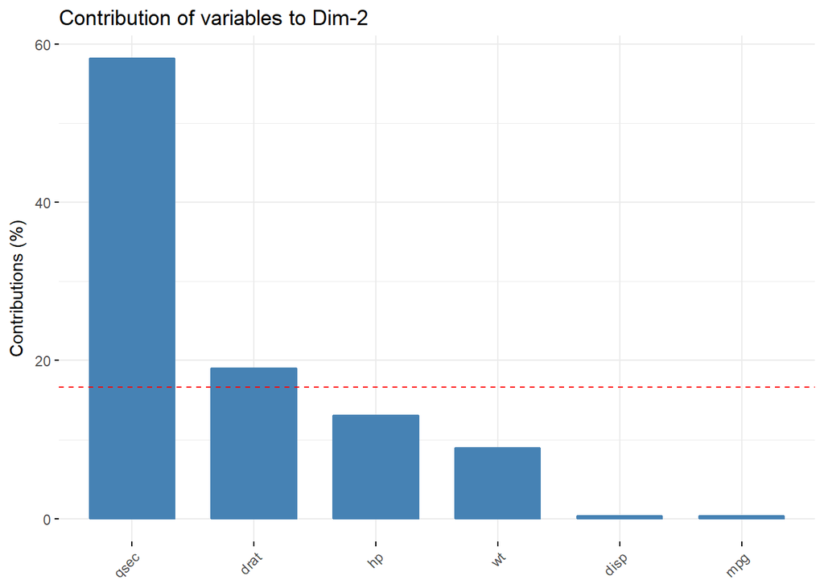

```r
fviz_contrib(PCAreduced,choice = "var",axes = 2, top = 10)  #dim 2
```

### 2. Correspondence analysis of three pairs of fields

Correspondence analysis is performed for categorcal and ordinal variables, therefore following pairs were chosen:

- cylinders and carburetors
- gear vs. carburetors
- cylinders vs. gear

#### 2.1. Cylinders vs. carburetors

CA biplot shows that all engine configurations are far one from another except the ones that have 3 or 8 carburetors and 8 cylinders.

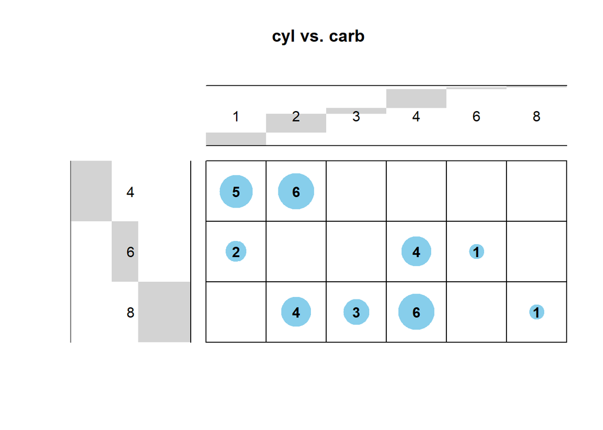

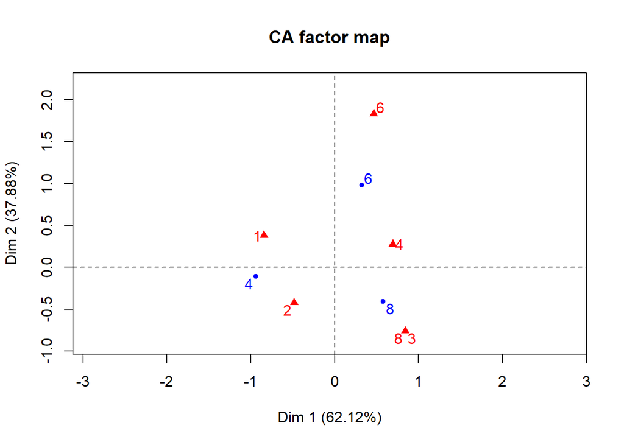

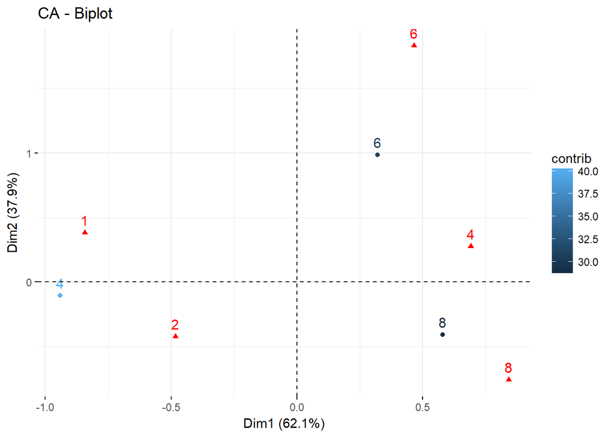

```
##       percentage of variance cumulative percentage of variance
## dim 1               62.11946                          62.11946
## dim 2               37.88054                         100.00000
```

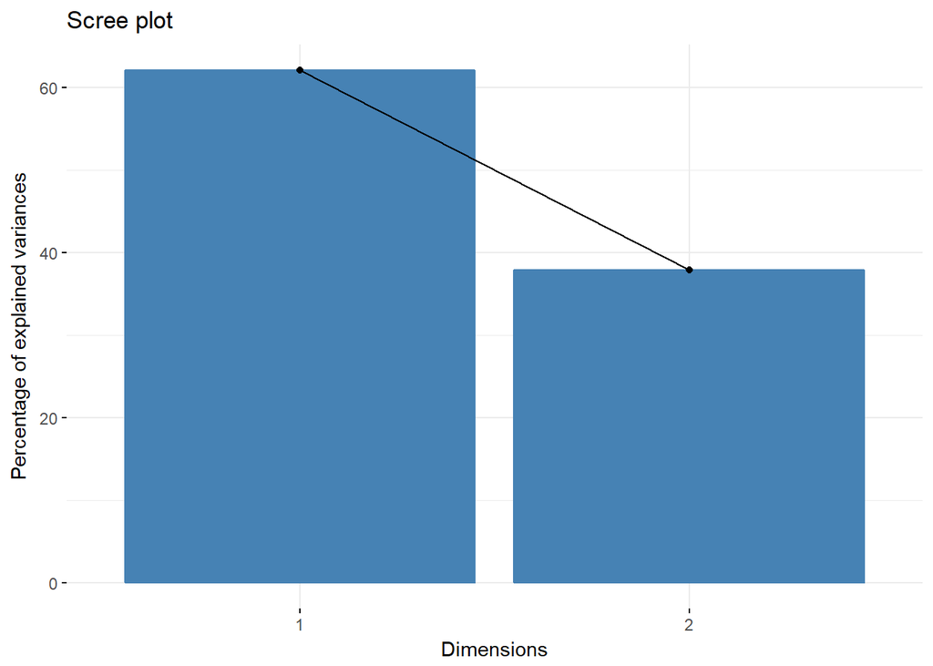

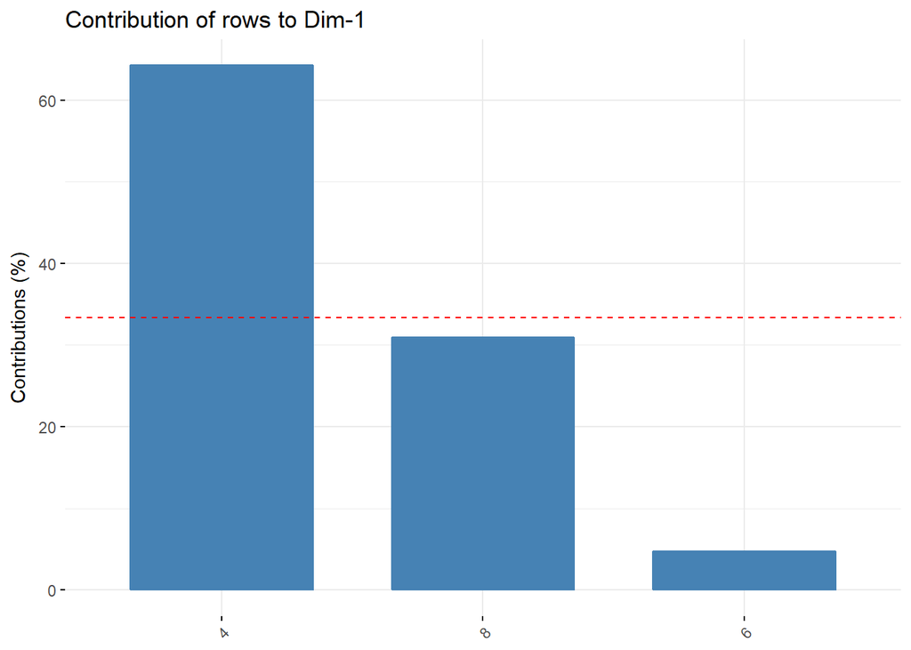

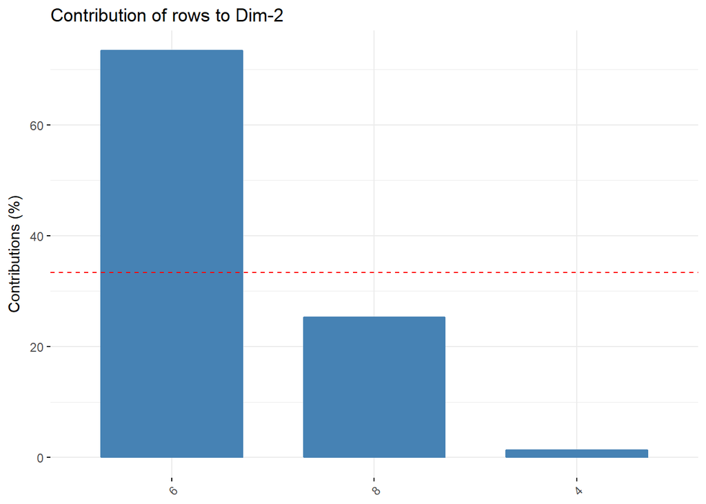

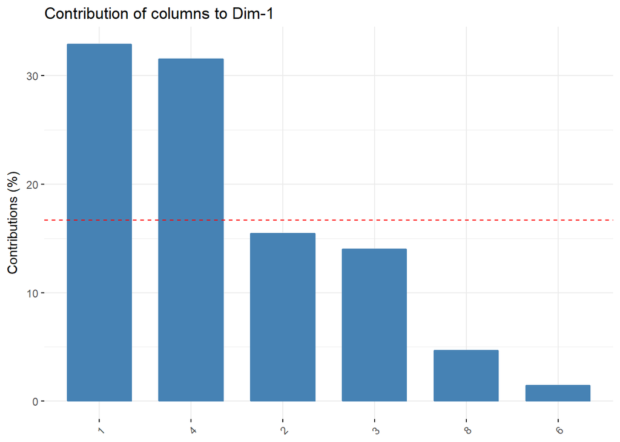

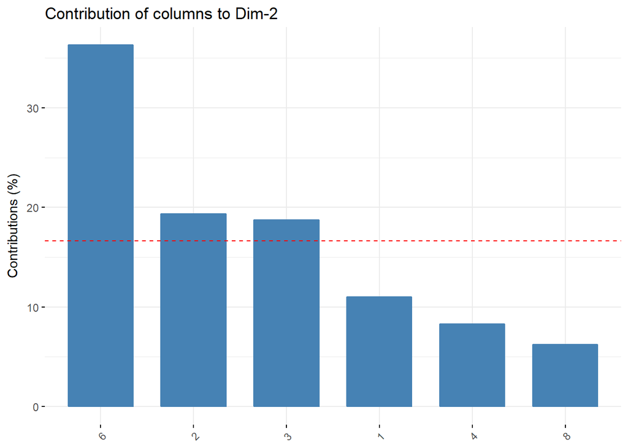

### 2.2. gear vs. carburetors

Balloonplot depicts that most commonly analysed cars have 3 or 4 gears along with 1 to 4 carburetors.Five gears come along with 6 or 8 carburetors. However two entities have 2 carburetors and 5 gears.Both are middle class cars - expensive sports cars, but not exclusive.

CA factor map indicates that engines with 6 and 8 carburetors are placed in the same point and are the close to 5 gears.

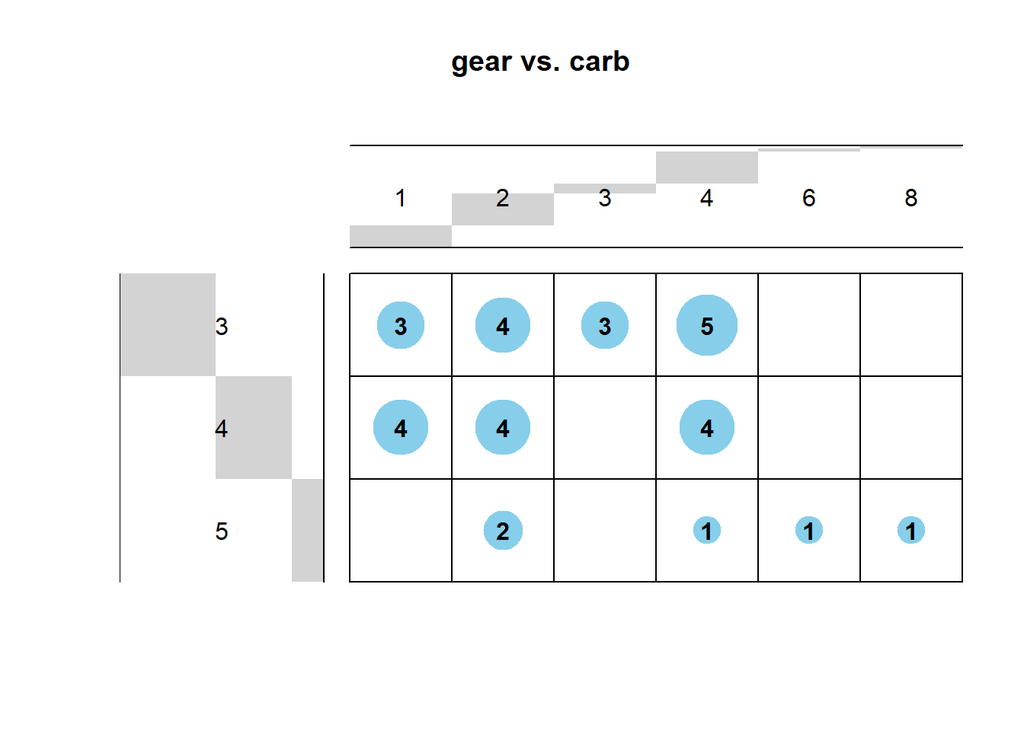

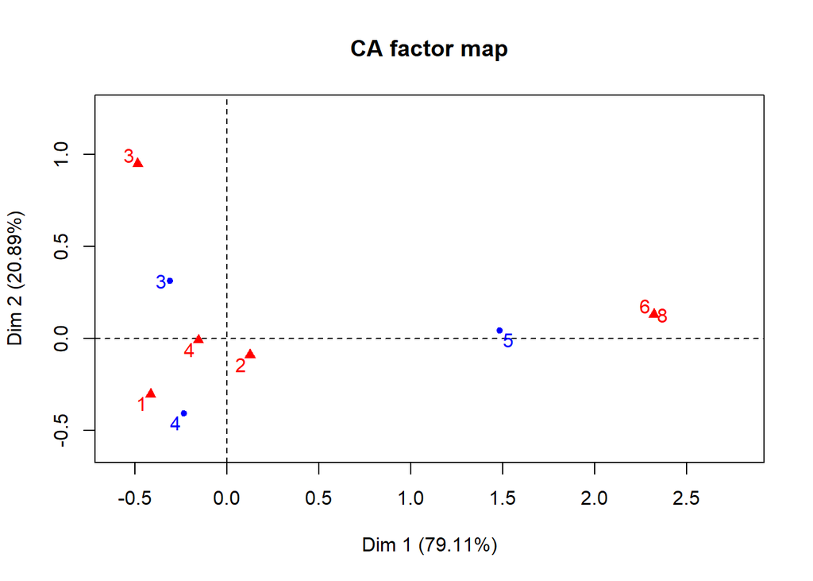

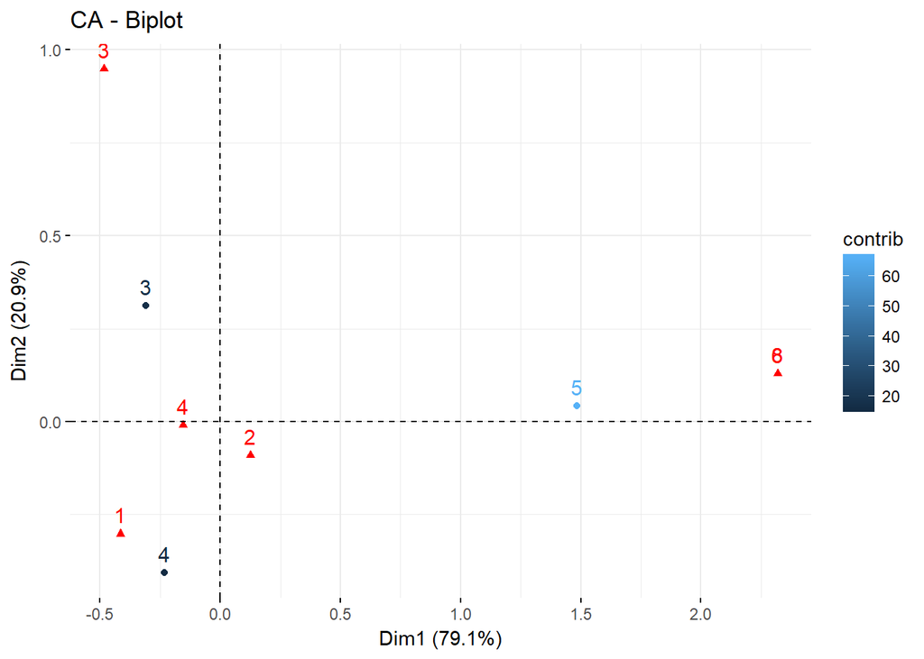

```
##       percentage of variance cumulative percentage of variance
## dim 1               79.10747                          79.10747
## dim 2               20.89253                         100.00000
```

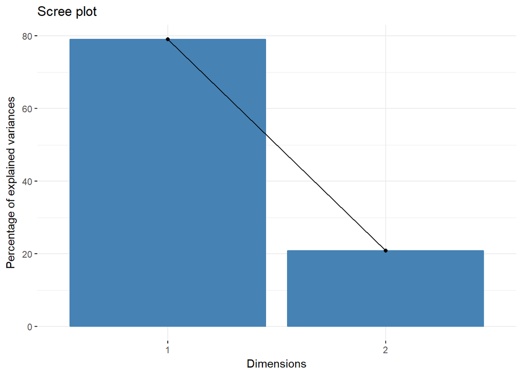

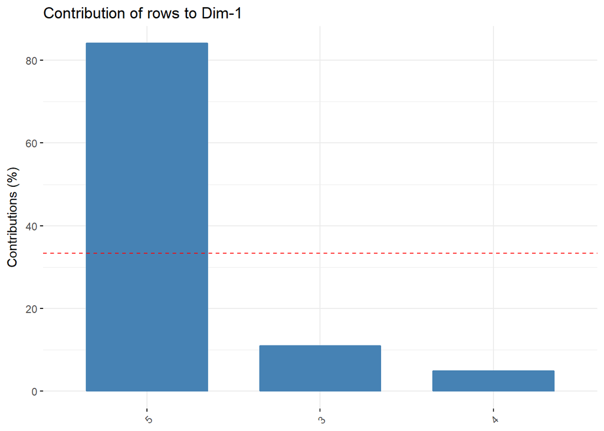

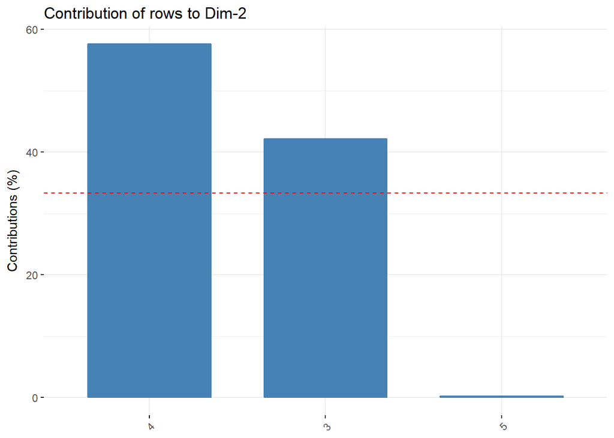

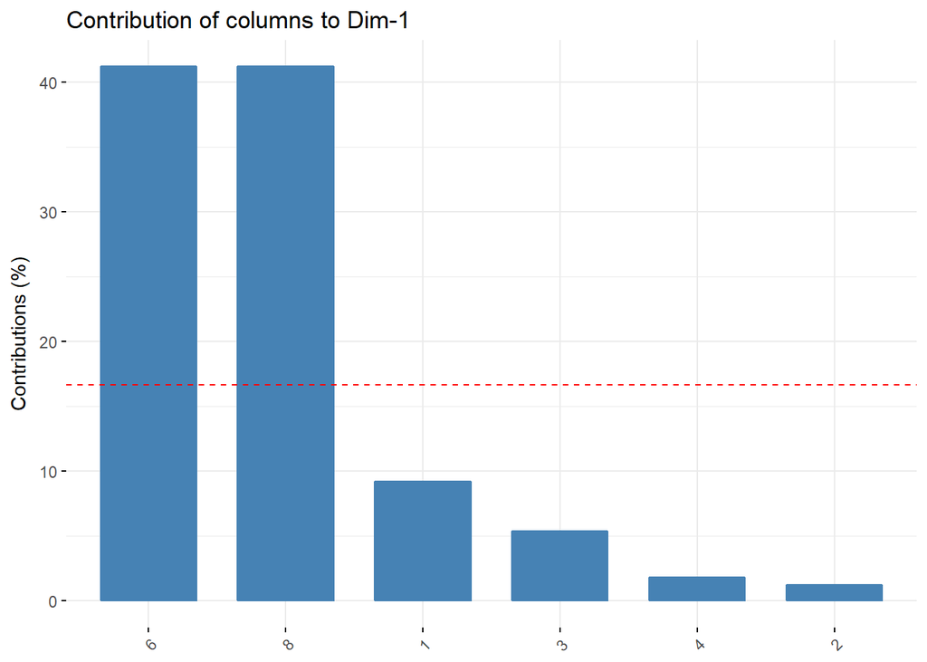

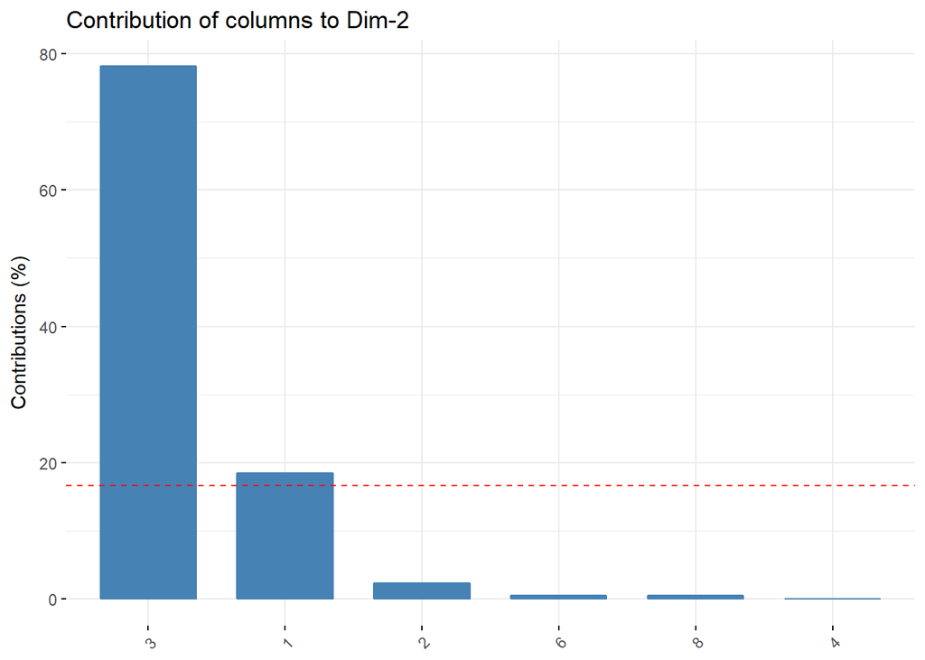

### 2.3. Cylinders vs. gear

Balloonplot shows that most cars have 8 cylinders and 3 gears, another popular setting is 4 cylinders with 4 gears.

Contribution plots show that the least variability is delivered by 6 cylinders and 5 gears. Variability in the second direction is neglectible. The strong data variability exists only in PCA1 direction. Points denoting 8 cylinders and 3 gears are close, which means they are commonly used in common. Similarly points denoting 4 gears and 4 cylinders are close. That shows that these are the typcal constructions.

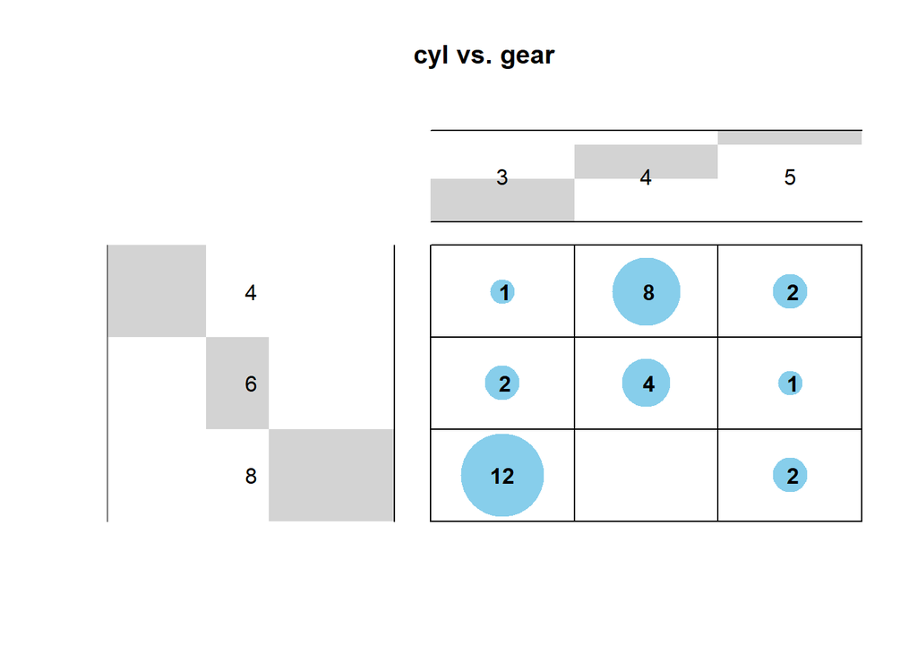

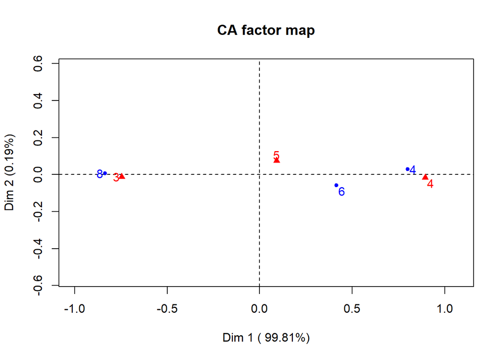

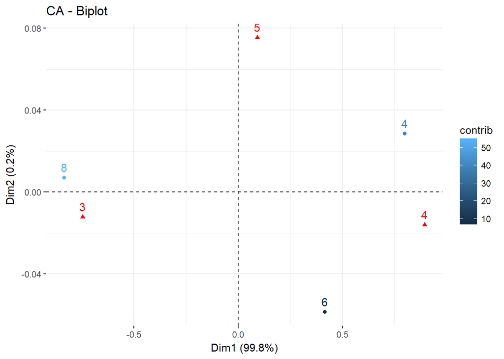

```
##       percentage of variance cumulative percentage of variance
## dim 1             99.8127693                          99.81277
## dim 2              0.1872307                         100.00000
```

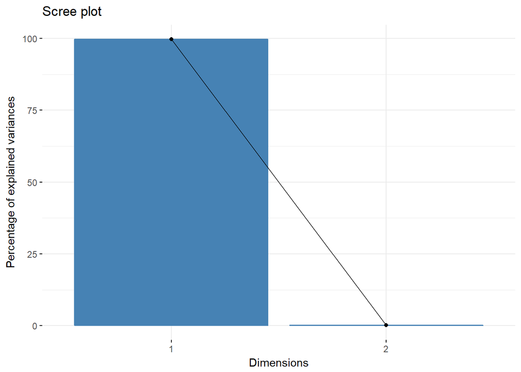

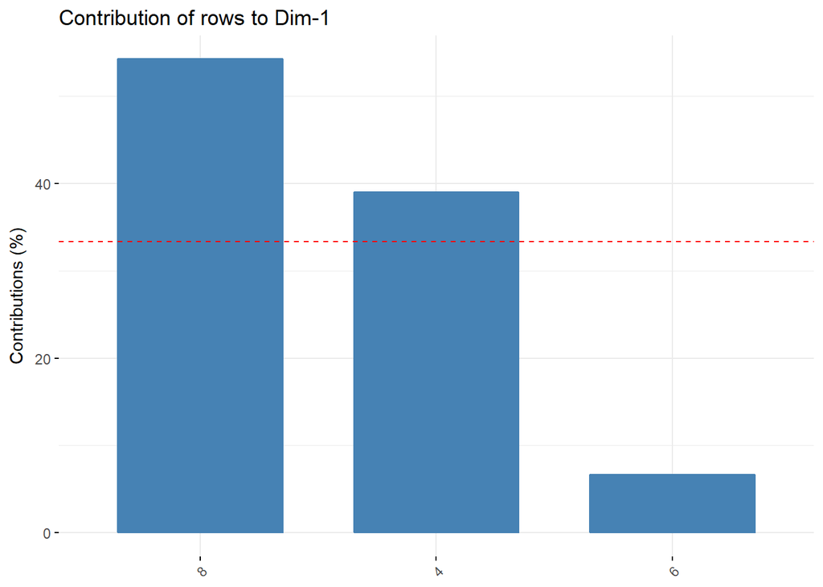

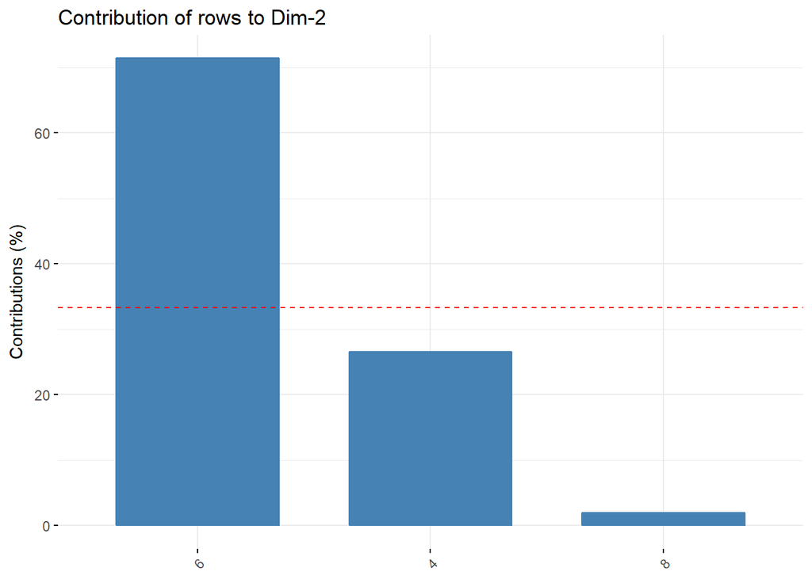

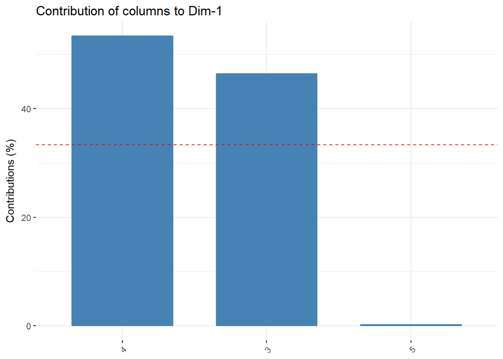

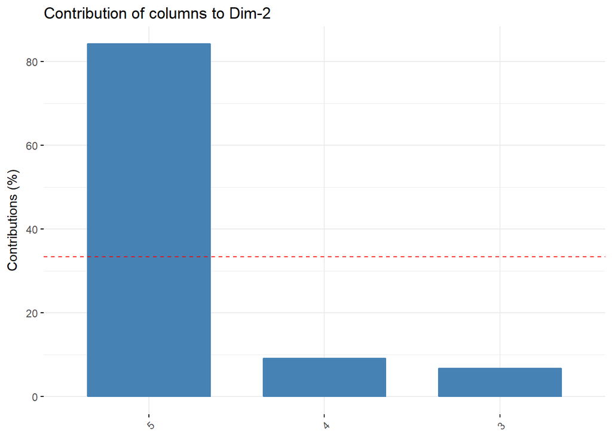